# Public Finances

Session 1

Luis F. Gómez L.

luis.gomezl@unimilitar.edu.co

Distance Learning Faculty

5 February, 2026

# Please Read Me

- Check the message **Welcome greeting** published in Announcements forum.
- Dear student please edit your profile uploading a photo where your face is clearly visible.
- If you want to participate, please fill out the following survey: **Primer corte 30% > Learning Activities > Tu opinión sobre la economía colombiana**
- This presentation is based on (Cardenas, 2020, Chapter 6)
- **Purpose**
  - Explain the role of the State in the economy

# Economic functions of government

- What are the economic functions of government? (Education, 2010, pp. 45–54)
  - **Maintain the Legal and Social Framework**
    - Define and enforce property rights
    - Establish a monetary system
  - **Maintain competition in the marketplace**
    - Create and enforce antitrust laws
    - Regulate natural monopolies
  - **Provide public goods and services**
    - Some goods and services are not provided by the market in the quantities desired by society
- What are the economic functions of government? (Education, 2010, pp. 45–54)
  - **Correct for externalities**
    - Reduce negative externalities
    - Encourage increased production of goods and services that have positive externalities
  - **Stabilize the economy**
    - Reduce unemployment and inflation
    - Promote economic growth
  - **Redistribute income**
    - Targeting public spending
    - Collect taxes

# Colombian public sector

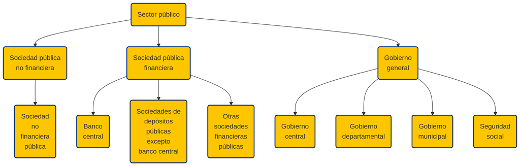

Figure 1: Division based on (Fund, 2014, Figure 2.3) and **Clasificación entidades según Código Único Institucional - CUIN**[^1]

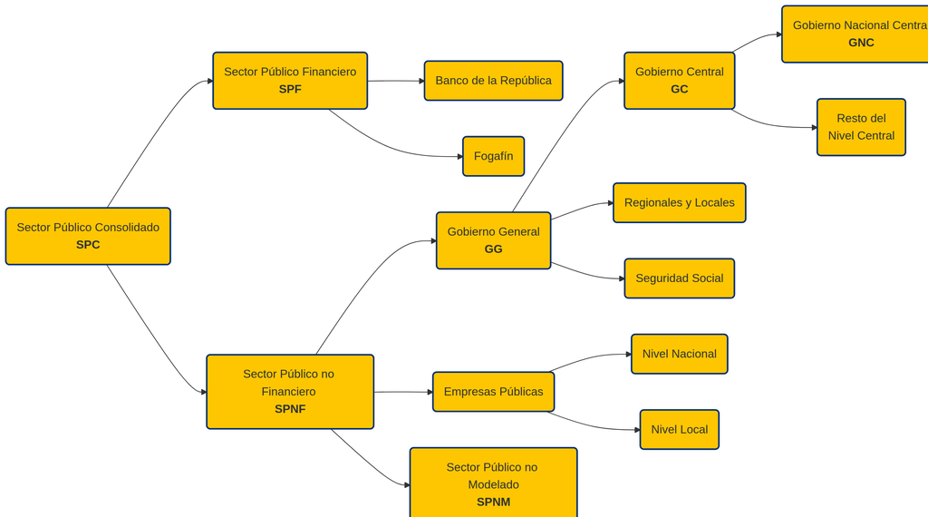

Figure 2: Division based on how the difference balances are reported by MinHacienda[^2]

- Central National Government (Gobierno Nacional Central (GNC)) Fiscal Balance
  - The fiscal balance is the difference between the central national government’s revenues and its expenditures
  - It shows the extent to which expenditure in a given year is financed by the revenues collected in that year (OECD, 2021, p. 68)
    - When the central national government spends more than it collects as revenues, it has a **fiscal deficit**
    - When the central national government spends less than it collects as revenues, it has a **fiscal surplus**

Table 1: Ingresos tributarios y no tributarios (% PIB)

| Concepto | 2024<sup>a</sup> |
| --- | --- |
| INGRESOS CORRIENTES DE LA NACION | 14.48 |
| INGRESOS TRIBUTARIOS | 14.37 |
| DIAN | 14.30 |
| Renta | 6.83 |
| IVA interno | 3.80 |
| IVA externo | 2.18 |
| Gravamen arancelario | 0.00 |
| Sobretasa a la Importaciones CIF | 0.00 |
| Imp. Nacional a la Gasolina y ACPM | 0.13 |
| Impuesto al Carbono | 0.03 |
| Consumo | 0.20 |
| CREE | 0.00 |
| Sobretasa a la Gasolina y ACPM | 0.00 |
| Gravamen movimientos financieros | 0.82 |
| Impuestos saludables y de plastico | 0.12 |
| Resto | 0.07 |
| Timbre | 0.01 |
| Impuesto SIMPLE | 0.09 |
| Normalización | 0.00 |
| Retención en la fuente inmuebles | 0.00 |
| Contribución para la Democracia (Patrimonio) / Impuesto a la riqueza | 0.09 |

<sup>a</sup> %PIB - Cierre fiscal  
Source: Ministerio de Hacienda y Crédito Público - Balance Gobierno Nacional Central  
Last update: 2025-01-09

Table 2: Ingresos tributarios y no tributarios (% PIB)

| Concepto | 2024<sup>a</sup> |
| --- | --- |
| INGRESOS CORRIENTES DE LA NACION | 14.48 |
| INGRESOS NO TRIBUTARIOS | 0.11 |
| Contribución de Hidrocarburos | 0.00 |
| Concesiones | 0.00 |
| Resto | 0.11 |

<sup>a</sup> %PIB - Cierre fiscal  
Source: Ministerio de Hacienda y Crédito Público - Balance Gobierno Nacional Central  
Last update: 2025-01-09

Table 3: Ingresos totales (% PIB)

| Concepto | 2024<sup>a</sup> |
| --- | --- |
| 1. INGRESOS TOTALES (SIN CAUSADOS) | 16.50 |
| INGRESOS CORRIENTES DE LA NACION | 14.48 |
| INGRESOS TRIBUTARIOS | 14.37 |
| INGRESOS NO TRIBUTARIOS | 0.11 |
| FONDOS ESPECIALES | 0.30 |
| OTROS RECURSOS DE CAPITAL | 1.72 |
| Rendimientos Financieros Totales | 0.00 |
| Excedentes Financieros | 1.47 |
| Ecopetrol | 0.67 |
| Banco de la República | 0.54 |
| Telecom | 0.00 |
| Isa e Isagen | 0.00 |
| Bancóldex | 0.00 |
| Estapúblicos | 0.23 |
| Resto de empresas | 0.03 |
| Recuperación de cartera diferente SPNF | 0.00 |
| Otros recursos | 0.25 |
| Reintegros y recursos no apropiados | 0.30 |
| Resto | −0.04 |

<sup>a</sup> %PIB - Cierre fiscal  
Source: Ministerio de Hacienda y Crédito Público - Balance Gobierno Nacional Central  
Last update: 2025-01-09

Table 4: Ingresos y pagos totales (% PIB)

| Concepto | 2024<sup>a</sup> |
| --- | --- |
| 1. INGRESOS TOTALES (SIN CAUSADOS) | 16.50 |
| INGRESOS CORRIENTES DE LA NACION | 14.48 |
| INGRESOS TRIBUTARIOS | 14.37 |
| INGRESOS NO TRIBUTARIOS | 0.11 |
| FONDOS ESPECIALES | 0.30 |
| OTROS RECURSOS DE CAPITAL | 1.72 |
| 2. PAGOS TOTALES | 22.67 |
| PAGOS TOTALES SIN INTERESES | 16.91 |
| PAGOS CORRIENTES DE LA NACION | 20.71 |
| INTERESES | 3.80 |
| Intereses deuda externa | 0.88 |
| Intereses deuda interna | 2.93 |
| Costo impuesto endeudamiento externo | 0.00 |
| FUNCIONAMIENTO | 16.91 |
| Servicios personales | 2.19 |
| Transferencias | 14.03 |
| Transferencias regionales (SGP desde 2002) | 3.98 |
| Pensiones | 3.56 |
| Otras | 6.49 |
| Gastos generales y otros | 0.68 |
| INVERSION | 1.96 |

<sup>a</sup> %PIB - Cierre fiscal  
Source: Ministerio de Hacienda y Crédito Público - Balance Gobierno Nacional Central  
Last update: 2025-01-09

Table 5: Balance fiscal gobierno nacional central (% PIB)

[output not shown]

<sup>a</sup> %PIB - Cierre fiscal  
Source: Ministerio de Hacienda y Crédito Público - Balance Gobierno Nacional Central  
Last update: 2025-01-09

Table 6: Balance fiscal gobierno nacional central (COP)

| Concepto | 2024<sup>a</sup> |
| --- | --- |
| 1. INGRESOS TOTALES (SIN CAUSADOS) | 281,460,224,806,615 |
| INGRESOS CORRIENTES DE LA NACION | 246,935,228,656,677 |
| INGRESOS TRIBUTARIOS | 245,050,082,504,388 |
| INGRESOS NO TRIBUTARIOS | 1,885,146,152,289 |
| FONDOS ESPECIALES | 5,182,737,081,858 |
| OTROS RECURSOS DE CAPITAL | 29,342,259,068,080 |
| 2. PAGOS TOTALES | 386,644,456,080,309 |
| PAGOS TOTALES SIN INTERESES | 288,317,833,747,620 |
| PAGOS CORRIENTES DE LA NACION | 353,170,601,838,946 |
| INTERESES | 64,852,768,091,327 |
| FUNCIONAMIENTO | 288,317,833,747,620 |
| INVERSION | 33,473,854,241,362 |
| 3. DEFICIT O SUPERAVIT EFECTIVO | -105,184,231,273,694 |
| PRESTAMO NETO | -146,971,981,940 |
| INGRESOS CAUSADOS | 0 |
| GASTOS CAUSADOS | 9,357,855,072,222 |
| DEUDA FLOTANTE | 115,755,148,429 |
| 4. DEFICIT O SUPERAVIT TOTAL | -114,510,869,512,404 |
| 5. COSTOS DE LA REEST. FINANCIERA | 0 |
| 6. DEFICIT A FINANCIAR | -114,510,869,512,404 |
| BALANCE PRIMARIO | -40,300,246,348,856 |

# Revenues: taxes

- Useful resources
  - **Global Revenue Statistics Database**
    - [**https://data-explorer.oecd.org/**](https://data-explorer.oecd.org/) > Taxation > Global tax revenues > Revenue Statistics in Latin America and the Caribbean - Comparative tax revenues
  - **Guía ciudadana a la tributación y el gasto del Estado colombiano** (Universidad Javeriana, 2018)
    - [**https://www.ofiscal.org/guias**](https://www.ofiscal.org/guias) > Tributación y gasto del Estado colombiano > Ver guía
- **Taxes**: “compulsory unrequited payments to the general government or to a supranational authority” (OECD, 2020, p. 319)
  - *“Taxes are unrequited in the sense that benefits provided by government to taxpayers are not normally in proportion to their payments”* (OECD, 2020, p. 319)
  - *“The term **tax** does not include fines, penalties and compulsory loans paid to government”* (OECD, 2020, p. 319)
  - Compulsory social security contributions and paid to general government are treated here as tax revenues (OECD, 2020, p. 320)
- **Classification of Taxes by the OECD** (OECD, 2020, pp. 317–318)
  - 1000 Taxes on income, profits and capital gains (Impuestos sobre la renta, las utilidades y las ganancias de capital)
  - 2000 Social security contributions (Contribuciones a la seguridad social)
  - 3000 Taxes on payroll and workforce (Impuestos sobre la nómina y la fuerza de trabajo)
  - 4000 Taxes on property (Impuestos sobre la propiedad)
  - 5000 Taxes on goods and services (Impuestos sobre los bienes y servicios)
  - 6000 Other taxes (Otros impuestos)
- According to the Colombia’s political constitution:
  - *“ARTICULO 363. El sistema tributario se funda en los principios de **equidad**, **eficiencia** y **progresividad**. …”*
- **Equity**

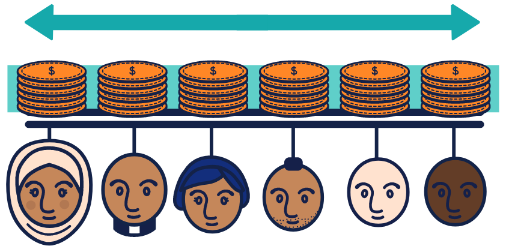

(a) Horizontal

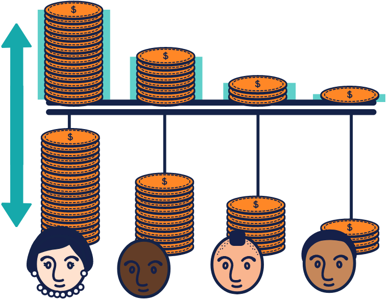

(b) Vertical

Figure 3: Horizontal and vertical equity (Universidad Javeriana, 2018, p. 8)

- **Efficiency**: taxes change the behavior of individuals and sometimes distort the economic activity by creating a deadweight loss. Therefore the idea is to have a tax system that minimize or mitigate these negative effects
- **Progressivity**

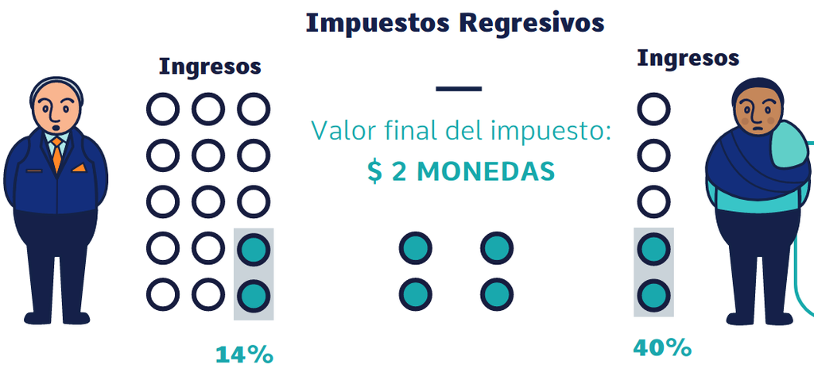

(a) Regressive

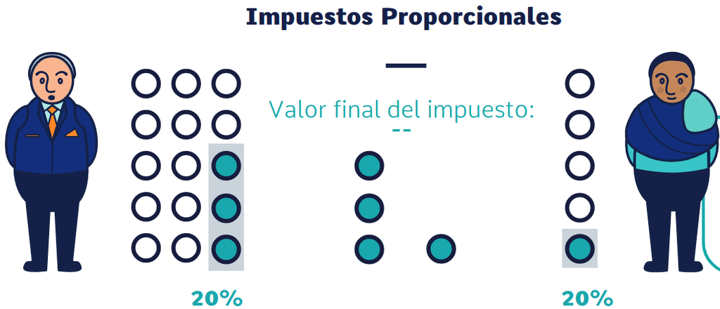

(b) Proportional

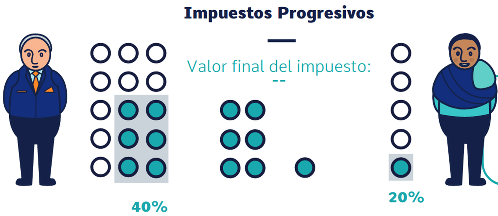

(c) Progressive

Figure 4: Regressive, proportional and progressive tax (Universidad Javeriana, 2018, p. 11)

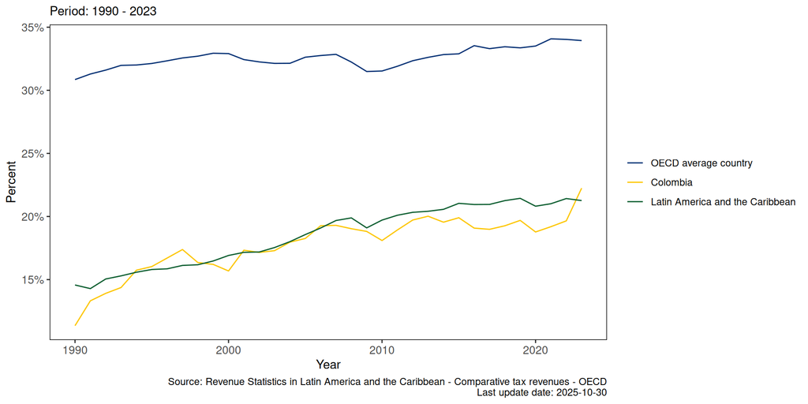

Figure 5: Total tax revenue as % of Gross Domestic Product

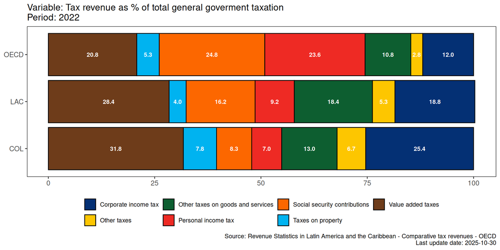

Figure 6: Tax structures for Colombia (COL), Latin America and the Caribbean (LAC) and OECD

# Acknowledgments

- To my family that supports me
- To the taxpayers of Colombia and the [**UMNG students**](https://www.umng.edu.co/estudiante) who pay my salary
- To the [**Business Science**](https://www.business-science.io/) and [**R4DS Online Learning**](https://www.rfordatasci.com/) communities where I learn [**R**](https://www.r-project.org/about.html) and [**$\pi$-thon**](https://www.python.org/about/)
- To the [**R Core Team**](https://www.r-project.org/contributors.html), the creators of [**RStudio IDE**](https://posit.co/download/rstudio-desktop/), [**Positron**](https://positron.posit.co/), [**Quarto**](https://quarto.org/) and the authors and maintainers of the packages [**tidyverse**](https://CRAN.R-project.org/package=tidyverse), [**readxl**](https://CRAN.R-project.org/package=readxl), [**gt**](https://CRAN.R-project.org/package=gt), [**scales**](https://CRAN.R-project.org/package=scales), [**janitor**](https://CRAN.R-project.org/package=janitor) and [**tinytex**](https://CRAN.R-project.org/package=tinytex) for allowing me to access these tools without paying for a license

# References

Cardenas, M. (2020). *Introducción a la Economía Colombiana* (4th ed.). Alfaomega.

Education, C. F. E. (2010). *Focus: Understanding economics in civics and government*.

Fund, I. M. (Ed.). (2014). *Government finance statistics manual 2014*. IMF.

OECD. (2020). *Revenue Statistics 2020*. OECD. https://doi.org/10.1787/8625f8e5-en

OECD. (2021). *Government at a Glance 2021*. OECD. https://doi.org/10.1787/1c258f55-en

Universidad Javeriana, O. F. de la. (2018). *Guía ciudadana a la tributación y el gasto del Estado colombiano*. https://www.ofiscal.org/publicaciones

## Footnotes

[^1]: https://www.contaduria.gov.co/clasificacion-entidades-segun-cuin
[^2]: https://www.minhacienda.gov.co/politica-fiscal